# Tutorial Part IV — Getting started with animal movement

# Introduction

In this tutorial, I will show you how to get started with (real) animal movement data. To put it simple, animal movement data are just points in time and space, i.e. re-locations of an individual can be provided as a *data.frame* with four columns. An identifier for the individual is only needed if you have different animals in one data set, i.e. if you have collared several individuals with the same collar or already appended several data sets:

| Identifier | Timestamp | x_coordinate | y_coordinate |
| --- | --- | --- | --- |
| Fox_1 | 2022-01-01 08:10:04 | 13.47027 | 52.497802 |
| Fox_1 | 2022-01-01 08:15:04 | 13.47015 | 52.497813 |

From Course2_SpatialR, you might remember that these can be imported as simple .txt or .csv files. Once you know in which coordinate reference system (CRS) your coordinates are stemming from, you can **assign** it to the *data.frame*, thereby you are creating a geo-referenced data set: a *SpatialPointsDataframe* - Object (if you work with the R-package `{sp}`) or an *sf* - Object (with package `{sf}`). Looking at these x- and y-coordinates, you might remember that they look like angular units, e.g. decimal degrees, and the x-coordinate refers to longitude and the y-coordinate to latitude. Hence, we are dealing with EPSG-code 4326. Once you have imported and georeferenced your data, you can plot and thoroughly check the data.

Checking your data is a mandatory prerequisite before any analysis (see Zuur et al. 2010). With your movement data, you might have outliers in space (e.g. when you test your collars in location A which might be hundreds of kilometers from your actual trapping site), your data might not have been regularly sampled because the animal was hiding and there was no access to the satellite (weak GPS-signal) etc etc. This uneven sampling can affect calculations of speed, for example, and therefore a series of packages have been developed to deal with those issues in movement data, like `{move}`.

The most prominent movement analyses comprise home range estimation, calculations of habitat preference, behavioral analyses (e.g. Hertel et al. 2021) and detection of movement syndromes (personality differences) (Michelangeli et al. 2021). Some of the packages listed in the next chapter are designed for these analyses.

## Useful (web)sites and reading

- For analysis of telemetry data: packages **adehabitatHR, adehabitatLT, move,recurse, momentuHMM, moveHMM, ctmm, amt**
- Hertel, AG, Royauté, R, Zedrosser, A, Mueller, T. Biologging reveals individual variation in behavioural predictability in the wild. J Anim Ecol. 2021; 90: 723– 737. https://doi.org/10.1111/1365-2656.13406
- Joo, R, Boone, ME, Clay, TA, Patrick, SC, Clusella-Trullas, S, Basille, M. Navigating through the r packages for movement. J Anim Ecol. 2020; 89: 248– 267. https://doi.org/10.1111/1365-2656.13116
- Kimmig, S (2021). The ecology of red foxes (*Vulpes vulpes*) in urban environments, PhD thesis, FU Berlin. https://refubium.fu-berlin.de/handle/fub188/32478
- Michelangeli, M., Payne, E., Spiegel, O., Sinn, D. L., Leu, S. T., Gardner, M. G., & Sih, A. (2021). Personality, spatiotemporal ecological variation and resident/explorer movement syndromes in the sleepy lizard. Journal of Animal Ecology, 00, 1– 14. https://doi.org/10.1111/1365-2656.13616
- Scholz, C (2020). The ecology of red foxes (*Vulpes vulpes*) in anthropogenic landscapes. PhD thesis, FU Berlin. https://refubium.fu-berlin.de/handle/fub188/29984
- Zuur, A.F., Ieno, E.N. and Elphick, C.S. (2010), A protocol for data exploration to avoid common statistical problems. Methods in Ecology and Evolution, 1: 3-14. https://doi.org/10.1111/j.2041-210X.2009.00001.x

# Getting started

To follow the tutorial, you can either clone or download the repository at https://github.com/stephkramer/Course4_MoveQ or you create your own R-project, copy the raw data and type the code chunks into an R-Script. Please refer to the section on using R-projects in [Course2_RSpatial](https://github.com/stephkramer/Course2_SpatialR).

If you start with your own R-project, I strongly recommend to use the d6-package Cedric Scherer provided. This package automatically sets up the ideal folder structure: https://github.com/EcoDynIZW/d6

In any case, my course folder has the following structure:

```bash
.
└── Course4_MoveQ
    ├── data-raw (contains the file with the GPS locations)
    ├── docs
    ├── output
    ├── plots
    └── R (contains the R-script)
```

## Necessary packages to install and load

We first have to install the packages and load them before we can use the functions we need.

```r
# package names:
pkgs = c("here", "sp", "sf", "dismo", "raster", "GISTools",  "rgdal",
         "maptools", "rgeos","rgl","rasterVis", "adehabitatHR", "move", "tmap",
         "plotly", "circular","gganimate","moveVis", "ggmap", "maps", "mapproj",
         "viridis","dplyr", "devtools","lubridate", "patchwork",
         "colorspace","ragg", "ggtext","pdftools", "units", "leaflet",
         "glue", "cowplot", "tidyverse", "ggplot2", "Cairo")

# install.packages(pkgs) # only run this line once for installing the packages!
# update.packages()
```

Tip of the day: If you have already installed some of the packages above, you can first check which ones are already installed, and save the ones *not installed* in an object called and only install the missing ones:

```r
# my_packages <- pkgs[!(pkgs %in% installed.packages()[,"Package"])]
# my_packages
# if(length(my_packages) > 0) install.packages(my_packages)
```

Now load the packages:

```r
library(here) #for easy directory management
library(sp)
library(dismo)
library(raster)
library(GISTools)
library(rgdal)    # retiring end of 2023 -> use stars/ terra /sf
library(maptools) # retiring end of 2023 -> use sp
library(rgeos)    # retiring end of 2023 -> use sf
library(rgl)
library(rasterVis)
library(adehabitatHR)  #adehabitatLT  #adehabitatMA
library(sf)
library(move)
library(plotly)
library(circular)
library(dplyr)
library(tmap)
library(viridis)
library(gganimate)
library(ggplot2)
library(moveVis)
library(ggmap)
library(maps)
library(mapproj)
library(devtools)
library(lubridate)
library(here)
library(glue)
library(cowplot)
library(tidyverse)
library(Cairo)
library(colorspace)
library(ragg)
library(ggtext)
library(pdftools)
library(units)
library(ggplot2)
library(patchwork) # to combine plots
library(leaflet)
```

## Set the working environment

Now that we are working inside an R-project, we can use the easy functionality of the `{here}` package, which is automatically pointing to your project’s root folder, e.g.:

```r
here::here()
```

```
## [1] "C:/Users/kramer/PopDynIZW Dropbox/Steph Kramer/_GitHub/Course4_MoveQ"
```

Hence, there is no need to use the function *setwd()* any more. Note: if it does not work, please close RStudio, go to your Explorer and double-click on the .Rproj file. Then, under ‘files’ (usually lower right panel) double-click on the R folder and open the script.

## Load data

The movement data are stored in the data-raw subfolder. Let’s check which files are available.

```r
lf <- list.files(path=here("data-raw"), full.names=TRUE)
lf
```

```
## [1] "C:/Users/kramer/PopDynIZW Dropbox/Steph Kramer/_GitHub/Course4_MoveQ/data-raw/geo-raw"
## [2] "C:/Users/kramer/PopDynIZW Dropbox/Steph Kramer/_GitHub/Course4_MoveQ/data-raw/tag5334_gps.txt"
```

The output lists two results, [1] is another subfolder, and [2] a text file. If you already know that your movement data contains e.g. ‘gps’ in its name or is stored as ‘.txt’ or ‘.csv’ files, you can directly search for those files with the *pattern* argument:

```r
# check the difference, and note: full.names was set to FALSE
list.files(path=here("data-raw"),pattern='gps',full.names=FALSE)
```

```
## [1] "tag5334_gps.txt"
```

Now load the data file. Our first fox filename should be ‘tag5334_gps.txt’.

```r
dat_anim <- read.table(file=lf[2], header=TRUE, fill=TRUE, sep=',')
```

### Data check

Let’s have a look at the data. This is the typical way data are stored on e-obs collars:

```r
dat_anim[1:5,] # recap: head(dat_anim) also works
```

```
##   key.bin.checksum tag.serial.number         start.timestamp longitude latitude
## 1       2135768252              5334 2018-10-30 04:00:00.000  13.47047 52.49499
## 2       2210577241              5334 2018-10-30 04:20:00.000  13.47157 52.49526
## 3       1824790132              5334 2018-10-30 04:40:00.000  13.47103 52.49525
## 4       4079427513              5334 2018-10-30 07:00:00.000  13.47109 52.49526
## 5        380027806              5334 2018-10-30 08:00:00.000  13.47105 52.49527
##   height.above.ellipsoid type.of.fix status used.time.to.get.fix
## 1                   76.3           3      A                   22
## 2                   81.6           3      A                   18
## 3                   66.5           3      A                   53
## 4                   73.5           3      A                   24
## 5                   71.1           3      A                   47
##          timestamp.of.fix battery.voltage fix.battery.voltage temperature
## 1 2018-10-30 04:00:23.000            3604                3389          10
## 2 2018-10-30 04:20:19.000            3616                3333          11
## 3 2018-10-30 04:40:54.000            3624                3374          13
## 4 2018-10-30 07:00:25.000            3659                3491          11
## 5 2018-10-30 08:00:48.000            3660                3470          13
##   speed.over.ground heading.degree speed.accuracy.estimate
## 1              1.64         233.31                    1.67
## 2              4.43         327.02                    3.79
## 3              0.07           0.00                    0.73
## 4              0.01           0.00                    0.65
## 5              0.04           0.00                    0.89
##   horizontal.accuracy.estimate
## 1                         7.94
## 2                        59.65
## 3                        15.36
## 4                         7.17
## 5                         8.45
```

For now, we will only work with few columns. **tag.serial.number** here refers to the individual identifier (collar ID). There are two columns with timestamps. **start.timestamp** is the preprogrammed time-interval. Then there is the **timestamp.of.fix**, which is the real time the GPS-location was recorded. This is usually a bit later, i.e.  
( = **start.timestamp** + **used.time.to.get.fix** + 1 second), as it takes some time for the collar unit to connect to the satellite. The spatial info is stored in the columns **longitude** and **latitude**.

Before you can transform the *data.frame* ‘dat_anim’ into a georeferenced spatial object, you need to check whether there are missing locations in your *data.frame*, otherwise you will get an error message on transformation. **This can happen if no GPS-signal could be recorded. Or - importantly - some collars are only activated when the animal is moving to save battery life. In that case, the missing GPS coordinates would correspond with the last position (= be the same). Depending on which analysis you want to do, e.g. define resting places, you might need to fill the missing positions again.**

```r
# if the latitude-entry is missing, the longitude value will also be missing
# so it is enough to only check the latitude
which(is.na(dat_anim$latitude)) #there are a lot of missing values in the locations
```

```
##   [1]   48   65   89   90   91  129  183  185  222  224  226  229  260  266  355
##  [16]  358  415  421  422  423  457  474  510  511  577  601  616  621  626  646
##  [31]  673  674  685  696  721  774  784  796  822  833  842  855  863  907  921
##  [46]  940  993 1006 1038 1070 1077 1078 1088 1126 1150 1159 1183 1188 1215 1238
##  [61] 1268 1272 1304 1330 1480 1516 1550 1552 1559 1600 1637 1680 1717 1721 1736
##  [76] 1738 1742 1772 1820 1824 1830 1867 1884 1973 1997 1999 2020 2023 2024 2025
##  [91] 2026 2064 2075 2076 2109 2162 2234 2313 2329 2374 2379 2396 2419 2453 2455
## [106] 2518 2551 2609 2614 2638 2687 2728 2745 2770 2776 2783 2800 2804 2805 2854
## [121] 2926 2927 2931 2935 2943 2950 2961 2963 2968 2990 2991 3043 3044 3052 3090
## [136] 3102 3114 3172 3225 3226 3305 3328 3361 3372 3373 3386 3409 3498 3516 3517
## [151] 3518 3520 3591 3622 3623 3624
```

```r
dat_anim_na <- dat_anim[!is.na(dat_anim$latitude),] #alternatively, use complete.cases()
```

Make the crosscheck if there is missing data in longitude:

```r
which(is.na(dat_anim_na$longitude)) # none
```

```
## integer(0)
```

### Data preparation

```r
# define date-time format - the format is year-month-day_hour:min:sec:
dat_anim_na$start.timestamp <- ymd_hms(dat_anim_na$start.timestamp, tz="Europe/Berlin")
```

Now append the information:

```r
dat_anim_na$yearday <- yday(dat_anim_na$start.timestamp)
dat_anim_na$month   <- month(dat_anim_na$start.timestamp)
dat_anim_na$hour    <- hour(dat_anim_na$start.timestamp)
dat_anim_na$kweek   <- week(dat_anim_na$start.timestamp)
dat_anim_na$date    <- date(dat_anim_na$start.timestamp)
# crosscheck with
# head(dat_anim_na)
```

In addition, we want to calulate the hours of sunset and sunrise as well as daylength. For this, we need to install a package that is still under development, i.e. which is not on CRAN. We therefore must download and install it locally:

```r
# devtools::install_github("bgctw/solartime") # run only once
library(solartime)
```

For computing sunset and sunrise, the latitude/ longitude must be provided as well:

```r
dat_anim_na$sunrise   <- computeSunriseHour(timestamp = dat_anim_na$start.timestamp,
                                            latDeg = dat_anim_na$latitude,
                                            longDeg = dat_anim_na$longitude)
dat_anim_na$sunset    <- computeSunsetHour(dat_anim_na$start.timestamp,
                                           dat_anim_na$latitude,
                                           dat_anim_na$longitude)
dat_anim_na$daylength <- computeDayLength(dat_anim_na$start.timestamp,dat_anim_na$latitude)
dat_anim_na$daytime   <- computeIsDayByLocation(dat_anim_na$start.timestamp,
                                                dat_anim_na$latitude,
                                                dat_anim_na$longitude)
# head(dat_anim_na)
```

Finally, we save the processed data file that we will use for exploration and analysis into the subfolder …‘output/data-proc’. There are two options

```r
# R data file - can only be opened/ read with R by using function readRDS()
saveRDS(dat_anim_na, file = here('output/data-proc/tag5334_gps_proc.Rds'))

# interchange file format .csv
write.csv(dat_anim_na, file = here('output/data-proc/tag5334_gps_proc.csv'))
```

Check your output folder for these files. The efficient ‘.Rds’ file storage is about 3 times smaller than the ‘.csv’ file.

# Exercise 4.1

This is recap from Course2. Please plot the animal relocations in two different colours for column ‘daytime’, using the *data.frame* and one of the options with ´{ggplot2}´,´{ggpmap}´ or ´{leaflet}´. Use the processed file of fox Q (tag5334_gps_proc) and do it in a separate script. Save your script as Course4_Exercise1_*yourname*.R .  
Hint: Remember to load the libraries. Note that you might want to plot the locations in the correct spatial dimensions by projecting it using the functions *st_as_sf()* and *st_transform()* .

# Data exploration

## Check for temporal outliers

```r
table(dat_anim_na$date)  #  there is a strange date - 2025-12-26
```

```
##
## 2018-10-30 2018-10-31 2018-11-01 2018-11-02 2018-11-03 2018-11-04 2018-11-05
##         24         40         35         39         42         34         34
## 2018-11-06 2018-11-07 2018-11-08 2018-11-09 2018-11-10 2018-11-11 2018-11-12
##         41         42         42         41         38         38         39
## 2018-11-13 2018-11-14 2018-11-15 2018-11-16 2018-11-17 2018-11-18 2018-11-19
##         41         38         34         38         44         34         35
## 2018-11-20 2018-11-21 2018-11-22 2018-11-23 2018-11-24 2018-11-25 2018-11-26
##         36         34         40         46         40         37         41
## 2018-11-27 2018-11-28 2018-11-29 2018-11-30 2018-12-01 2018-12-02 2018-12-03
##         43         39         34         42         45         37         39
## 2018-12-04 2018-12-05 2018-12-06 2018-12-07 2018-12-08 2018-12-09 2018-12-10
##         38         39         38         31         38         36         36
## 2018-12-11 2018-12-12 2018-12-13 2018-12-14 2018-12-15 2018-12-16 2018-12-17
##         39         34         38         37         37         43         43
## 2018-12-18 2018-12-19 2018-12-20 2018-12-21 2018-12-22 2018-12-23 2018-12-24
##         37         31         41         36         38         42         44
## 2018-12-25 2018-12-26 2018-12-27 2018-12-28 2018-12-29 2018-12-30 2018-12-31
##         32         30         38         38         36         37         39
## 2019-01-01 2019-01-02 2019-01-03 2019-01-04 2019-01-05 2019-01-06 2019-01-07
##         33         43         37         36         39         39         45
## 2019-01-08 2019-01-09 2019-01-10 2019-01-11 2019-01-12 2019-01-13 2019-01-14
##         36         38         41         33         26         35         40
## 2019-01-15 2019-01-16 2019-01-17 2019-01-18 2019-01-19 2019-01-20 2019-01-21
##         28         35         35         40         39         34         31
## 2019-01-22 2019-01-23 2019-01-24 2019-01-25 2019-01-26 2019-01-27 2019-01-28
##         36         36         34         36         43         34         33
## 2019-01-29 2019-01-30 2019-01-31 2025-12-26
##         35         34         27          1
```

```r
# Delete data row
delme <- which(dat_anim_na$date == '2025-12-26')
dat_anim_na[delme,]
```

```
##      key.bin.checksum tag.serial.number     start.timestamp longitude latitude
## 2622       2948730959              5334 2025-12-26 04:00:00  13.47851 52.49133
##      height.above.ellipsoid type.of.fix status used.time.to.get.fix
## 2622                   78.8           3      A                   23
##             timestamp.of.fix battery.voltage fix.battery.voltage temperature
## 2622 2025-12-26 04:00:24.000            3582                3287           3
##      speed.over.ground heading.degree speed.accuracy.estimate
## 2622              0.03              0                    0.64
##      horizontal.accuracy.estimate yearday month hour kweek       date  sunrise
## 2622                         4.35     360    12    4    52 2025-12-26 8.390617
##        sunset daylength daytime
## 2622 15.80777  7.417151   FALSE
```

```r
dat_anim_na <- dat_anim_na[-delme,] # delete the strange date and
table(dat_anim_na$date)             # check again
```

```
##
## 2018-10-30 2018-10-31 2018-11-01 2018-11-02 2018-11-03 2018-11-04 2018-11-05
##         24         40         35         39         42         34         34
## 2018-11-06 2018-11-07 2018-11-08 2018-11-09 2018-11-10 2018-11-11 2018-11-12
##         41         42         42         41         38         38         39
## 2018-11-13 2018-11-14 2018-11-15 2018-11-16 2018-11-17 2018-11-18 2018-11-19
##         41         38         34         38         44         34         35
## 2018-11-20 2018-11-21 2018-11-22 2018-11-23 2018-11-24 2018-11-25 2018-11-26
##         36         34         40         46         40         37         41
## 2018-11-27 2018-11-28 2018-11-29 2018-11-30 2018-12-01 2018-12-02 2018-12-03
##         43         39         34         42         45         37         39
## 2018-12-04 2018-12-05 2018-12-06 2018-12-07 2018-12-08 2018-12-09 2018-12-10
##         38         39         38         31         38         36         36
## 2018-12-11 2018-12-12 2018-12-13 2018-12-14 2018-12-15 2018-12-16 2018-12-17
##         39         34         38         37         37         43         43
## 2018-12-18 2018-12-19 2018-12-20 2018-12-21 2018-12-22 2018-12-23 2018-12-24
##         37         31         41         36         38         42         44
## 2018-12-25 2018-12-26 2018-12-27 2018-12-28 2018-12-29 2018-12-30 2018-12-31
##         32         30         38         38         36         37         39
## 2019-01-01 2019-01-02 2019-01-03 2019-01-04 2019-01-05 2019-01-06 2019-01-07
##         33         43         37         36         39         39         45
## 2019-01-08 2019-01-09 2019-01-10 2019-01-11 2019-01-12 2019-01-13 2019-01-14
##         36         38         41         33         26         35         40
## 2019-01-15 2019-01-16 2019-01-17 2019-01-18 2019-01-19 2019-01-20 2019-01-21
##         28         35         35         40         39         34         31
## 2019-01-22 2019-01-23 2019-01-24 2019-01-25 2019-01-26 2019-01-27 2019-01-28
##         36         36         34         36         43         34         33
## 2019-01-29 2019-01-30 2019-01-31
##         35         34         27
```

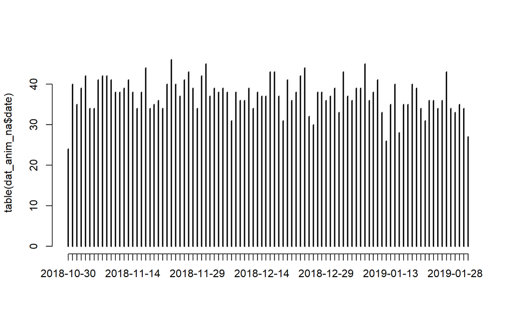

```r
plot(table(dat_anim_na$date))       # plot the number of fixes per day
```

The number of fixes (locations taken) per day seems to be quite regular.

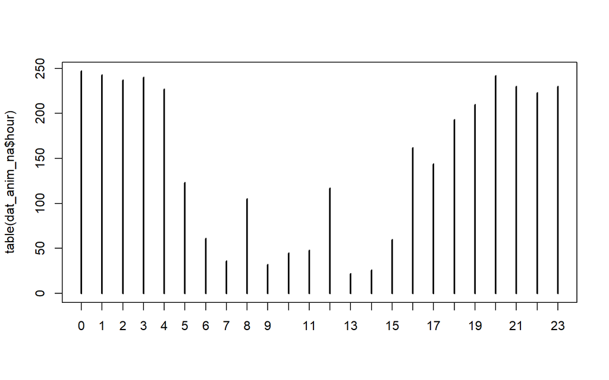

```r
plot(table(dat_anim_na$hour))       # plot the number of fixes per hour
```

More fixes during the night - this is the active phase. As these are circular data, we can plot the number of fixes as sign for activity (knowing that our collars did not record when foxes were inactive).

### Plot activity

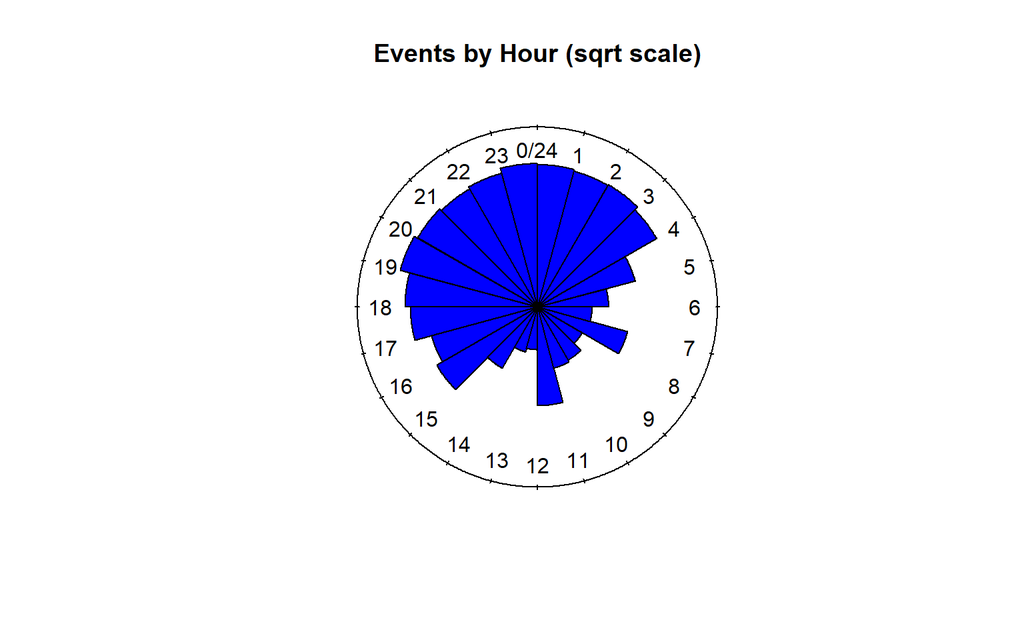

```r
# simple
timetoplot <- circular(dat_anim_na$hour%%24, # convert to 24 hrs
                       units="hours", template="clock24")
rose.diag(timetoplot, bin=24, col="blue",
          main="Events by Hour (sqrt scale)", prop=3)
```

Check whether the activity during the day was before sunrise:

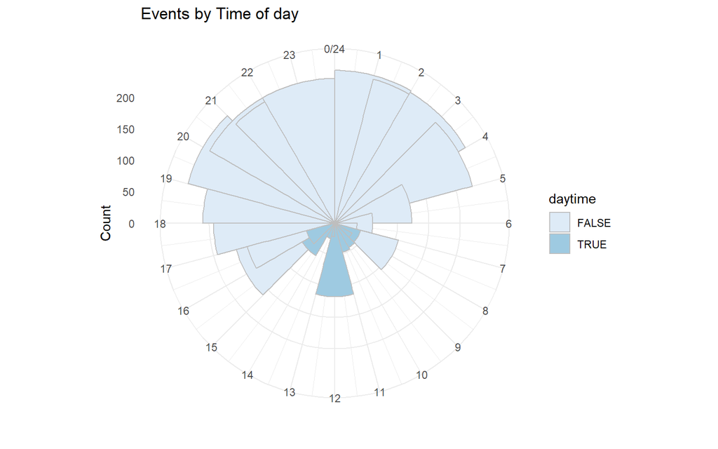

```r
# with ggplot
# code adapted from https://gist.github.com/mattbaggott/4361381
ggplot(dat_anim_na,aes(x=hour,fill=daytime))+
  geom_bar(breaks=seq(0,24),width = 2,colour="grey")+
  coord_polar(start=0)+
  theme_minimal()+
  scale_fill_brewer()+
  ylab("Count")+
  ggtitle("Events by Time of day")+
  scale_x_continuous("", limits=c(0,24),
                     breaks=seq(0,24),
                     labels=seq(0,24))
```

## Check for spatial outliers

### Data transformation

Now we can transform the data into *sf* and *sp* objects and **assign** the coordinate reference system:

```r
# transform into spatial simple feature sf object
mydf_sf <- st_as_sf(x = data.frame(dat_anim_na),
                       coords = c("longitude", "latitude"),
                       crs = 4326,
                       sf_column_name = "geometry" )

# transform into SpatialPointsDataFrame  - for crosschecking
mydf_sp <- as(mydf_sf, "Spatial")
```

And then we **project** the reference system from angular units to a planar coordinate reference system in meters:

```r
# transform CRS to projected one in meter distance units
mydf_sf_trans <-  st_transform(mydf_sf, 5631 )  # EPSG-code Pulkovo
mydf_sp_trans <-  spTransform(mydf_sp, CRS("+init=epsg:5631"))
```

Recap for styling the plot: https://www.r-bloggers.com/2021/12/introduction-to-geospatial-visualization-with-the-tmap-package/

```r
tmap_mode(mode = "view")
  tm_shape(shp = mydf_sf_trans)  + tm_dots(size = 0.01,
                                           col = 'daytime',
                                           alpha=0.5)
```

[interactive chart not shown]

Have a deep look at the data: did the fox really swim? (points in Lake Rummelsburg). Or are these outliers? No: the lake was frozen! Note: you really need to know your animal and the area!